# Examen final PEIA - Informe

## Grupo 5

- a1612 - Christopher Charaf Herrera
- a1618 - Myrna Degano
- a1620 - Gustavo Rivas

## Planteamiento de los problemas de investigación:

### a) Analizar el comportamiento de las ventas en cada mes para ambas tiendas.

### b) Analizar el comportamiento de las ventas en cada día de la semana para ambas tiendas.

### c) Comparar las ventas entre las tiendas 'Santa Ana' y 'La Floresta'.

## Procesamiento realizado a los datos:

- Se cargaron los datos de ambas tiendas en dataframes de pandas.
- Se añadieron columnas para mes y día de la semana.
- Se calcularon las distribuciones empíricas, funciones de densidad e intervalos de confianza para cada mes y día de la semana.
- Se realizó una prueba de hipótesis (t-test) para comparar las ventas entre ambas tiendas.

## Resultados encontrados:

### Tienda La Floresta

| Fecha | Ventas |
| --- | --- |
| 2023-01 | 518276.809601 |
| 2023-02 | 525269.955847 |
| 2023-03 | 652387.603906 |
| 2023-04 | 599982.260459 |
| 2023-05 | 662528.437527 |
| 2023-06 | 686416.727300 |
| 2023-07 | 635172.453200 |
| 2023-08 | 676583.099018 |
| 2023-09 | 673080.085808 |
| 2023-10 | 680830.785203 |
| 2023-11 | 671415.583088 |
| 2023-12 | 616486.833443 |

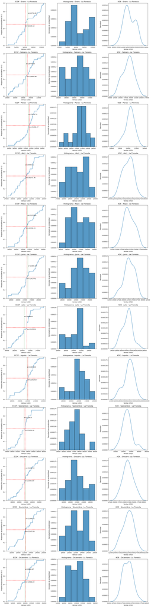

Intervalos de confianza La Floresta

**La Floresta - Ventas enero (USD)**

|  | Límite inferior | Media | Límite superior |
| --- | --- | --- | --- |
| 95% | 15863.27 | 16718.61 | 17870.35 |
| 99% | 15566.87 | 16718.61 | 17870.35 |

**La Floresta - Ventas febrero (USD)**

|  | Límite inferior | Media | Límite superior |
| --- | --- | --- | --- |
| 95% | 17768.69 | 18759.64 | 20097.76 |
| 99% | 17421.52 | 18759.64 | 20097.76 |

**La Floresta - Ventas marzo (USD)**

|  | Límite inferior | Media | Límite superior |
| --- | --- | --- | --- |
| 95% | 20002.89 | 21044.76 | 22447.68 |
| 99% | 19641.85 | 21044.76 | 22447.68 |

**La Floresta - Ventas abril (USD)**

|  | Límite inferior | Media | Límite superior |
| --- | --- | --- | --- |
| 95% | 18934.68 | 19999.41 | 21434.36 |
| 99% | 18564.46 | 19999.41 | 21434.36 |

**La Floresta - Ventas mayo (USD)**

|  | Límite inferior | Media | Límite superior |
| --- | --- | --- | --- |
| 95% | 20355.83 | 21371.89 | 22740.03 |
| 99% | 20003.74 | 21371.89 | 22740.03 |

**La Floresta - Ventas junio (USD)**

|  | Límite inferior | Media | Límite superior |
| --- | --- | --- | --- |
| 95% | 21867.75 | 22880.56 | 24245.53 |
| 99% | 21515.59 | 22880.56 | 24245.53 |

**La Floresta - Ventas julio (USD)**

|  | Límite inferior | Media | Límite superior |
| --- | --- | --- | --- |
| 95% | 19708.30 | 20489.43 | 21541.26 |
| 99% | 19437.61 | 20489.43 | 21541.26 |

**La Floresta - Ventas agosto (USD)**

|  | Límite inferior | Media | Límite superior |
| --- | --- | --- | --- |
| 95% | 21002.64 | 21825.26 | 22932.95 |
| 99% | 20717.57 | 21825.26 | 22932.95 |

**La Floresta - Ventas septiembre (USD)**

|  | Límite inferior | Media | Límite superior |
| --- | --- | --- | --- |
| 95% | 21313.20 | 22436.0 | 23949.23 |
| 99% | 20922.78 | 22436.0 | 23949.23 |

**La Floresta - Ventas octubre (USD)**

|  | Límite inferior | Media | Límite superior |
| --- | --- | --- | --- |
| 95% | 21000.44 | 21962.28 | 23257.44 |
| 99% | 20667.12 | 21962.28 | 23257.44 |

**La Floresta - Ventas noviembre (USD)**

|  | Límite inferior | Media | Límite superior |
| --- | --- | --- | --- |
| 95% | 21290.80 | 22380.52 | 23849.14 |
| 99% | 20911.89 | 22380.52 | 23849.14 |

**La Floresta - Ventas diciembre (USD)**

|  | Límite inferior | Media | Límite superior |
| --- | --- | --- | --- |
| 95% | 18954.06 | 19886.67 | 21142.46 |
| 99% | 18630.88 | 19886.67 | 21142.46 |

### Tienda Santa Ana

| Fecha | Ventas |
| --- | --- |
| 2023-01 | 465944.752336 |
| 2023-02 | 474841.524307 |
| 2023-03 | 608682.360394 |
| 2023-04 | 545824.012150 |
| 2023-05 | 586583.739500 |
| 2023-06 | 607980.537281 |
| 2023-07 | 588900.539186 |
| 2023-08 | 631206.190555 |
| 2023-09 | 622671.568131 |
| 2023-10 | 634822.962316 |
| 2023-11 | 611994.882407 |
| 2023-12 | 555473.758702 |

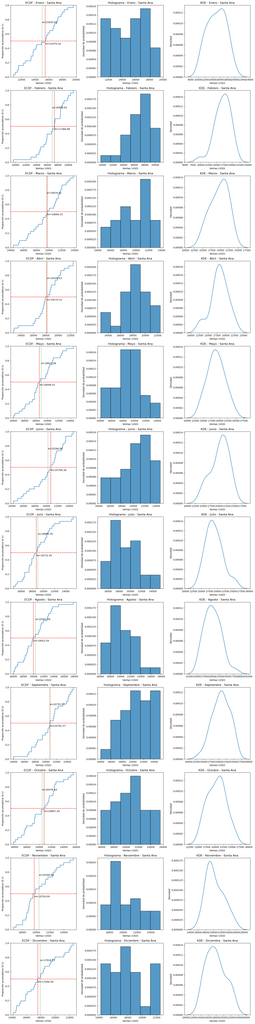

Intervalos de confianza Santa Ana

**Santa Ana - Ventas enero (USD)**

|  | Límite inferior | Media | Límite superior |
| --- | --- | --- | --- |
| 95% | 14120.01 | 15030.48 | 16256.45 |
| 99% | 13804.50 | 15030.48 | 16256.45 |

**Santa Ana - Ventas febrero (USD)**

|  | Límite inferior | Media | Límite superior |
| --- | --- | --- | --- |
| 95% | 15986.18 | 16958.63 | 18271.77 |
| 99% | 15645.48 | 16958.63 | 18271.77 |

**Santa Ana - Ventas marzo (USD)**

|  | Límite inferior | Media | Límite superior |
| --- | --- | --- | --- |
| 95% | 18702.64 | 19634.91 | 20890.26 |
| 99% | 18379.57 | 19634.91 | 20890.26 |

**Santa Ana - Ventas abril (USD)**

|  | Límite inferior | Media | Límite superior |
| --- | --- | --- | --- |
| 95% | 17284.58 | 18194.13 | 19419.96 |
| 99% | 16968.31 | 18194.13 | 19419.96 |

**Santa Ana - Ventas mayo (USD)**

|  | Límite inferior | Media | Límite superior |
| --- | --- | --- | --- |
| 95% | 17953.51 | 18922.06 | 20226.24 |
| 99% | 17617.87 | 18922.06 | 20226.24 |

**Santa Ana - Ventas junio (USD)**

|  | Límite inferior | Media | Límite superior |
| --- | --- | --- | --- |
| 95% | 19210.47 | 20266.02 | 21688.59 |
| 99% | 18843.45 | 20266.02 | 21688.59 |

**Santa Ana - Ventas julio (USD)**

|  | Límite inferior | Media | Límite superior |
| --- | --- | --- | --- |
| 95% | 18028.10 | 18996.79 | 20301.18 |
| 99% | 17692.41 | 18996.79 | 20301.18 |

**Santa Ana - Ventas agosto (USD)**

|  | Límite inferior | Media | Límite superior |
| --- | --- | --- | --- |
| 95% | 19340.83 | 20361.49 | 21735.85 |
| 99% | 18987.13 | 20361.49 | 21735.85 |

**Santa Ana - Ventas septiembre (USD)**

|  | Límite inferior | Media | Límite superior |
| --- | --- | --- | --- |
| 95% | 19694.35 | 20755.72 | 22186.13 |
| 99% | 19325.30 | 20755.72 | 22186.13 |

**Santa Ana - Ventas octubre (USD)**

|  | Límite inferior | Media | Límite superior |
| --- | --- | --- | --- |
| 95% | 19502.91 | 20478.16 | 21791.38 |
| 99% | 19164.94 | 20478.16 | 21791.38 |

**Santa Ana - Ventas noviembre (USD)**

|  | Límite inferior | Media | Límite superior |
| --- | --- | --- | --- |
| 95% | 19548.91 | 20399.83 | 21546.62 |
| 99% | 19253.04 | 20399.83 | 21546.62 |

**Santa Ana - Ventas diciembre (USD)**

|  | Límite inferior | Media | Límite superior |
| --- | --- | --- | --- |
| 95% | 16996.23 | 17918.51 | 19160.39 |
| 99% | 16676.62 | 17918.51 | 19160.39 |

### b) Análisis por día de la semana:

#### Tienda La Floresta

**La Floresta - Ventas LUNES (USD)**

|  | Límite inferior | Media | Límite superior |
| --- | --- | --- | --- |
| 95% | 19061.86 | 19739.59 | 20642.87 |
| 99% | 18836.31 | 19739.59 | 20642.87 |

**La Floresta - Ventas MARTES (USD)**

|  | Límite inferior | Media | Límite superior |
| --- | --- | --- | --- |
| 95% | 20945.26 | 21718.24 | 22748.47 |
| 99% | 20688.01 | 21718.24 | 22748.47 |

**La Floresta - Ventas MIÉRCOLES (USD)**

|  | Límite inferior | Media | Límite superior |
| --- | --- | --- | --- |
| 95% | 21876.93 | 22526.38 | 23391.96 |
| 99% | 21660.79 | 22526.38 | 23391.96 |

**La Floresta - Ventas JUEVES (USD)**

|  | Límite inferior | Media | Límite superior |
| --- | --- | --- | --- |
| 95% | 21862.10 | 22617.02 | 23623.19 |
| 99% | 21610.86 | 22617.02 | 23623.19 |

**La Floresta - Ventas VIERNES (USD)**

|  | Límite inferior | Media | Límite superior |
| --- | --- | --- | --- |
| 95% | 21184.22 | 21969.1 | 23015.19 |
| 99% | 20923.01 | 21969.1 | 23015.19 |

**La Floresta - Ventas SÁBADO (USD)**

|  | Límite inferior | Media | Límite superior |
| --- | --- | --- | --- |
| 95% | 18833.91 | 19616.02 | 20658.41 |
| 99% | 18573.62 | 19616.02 | 20658.41 |

**La Floresta - Ventas DOMINGO (USD)**

|  | Límite inferior | Media | Límite superior |
| --- | --- | --- | --- |
| 95% | 17009.25 | 17598.88 | 18384.54 |
| 99% | 16813.23 | 17598.88 | 18384.54 |

#### Tienda Santa Ana

**Santa Ana - Ventas LUNES (USD)**

|  | Límite inferior | Media | Límite superior |
| --- | --- | --- | --- |
| 95% | 17052.91 | 17719.76 | 18608.54 |
| 99% | 16830.98 | 17719.76 | 18608.54 |

**Santa Ana - Ventas MARTES (USD)**

|  | Límite inferior | Media | Límite superior |
| --- | --- | --- | --- |
| 95% | 19028.07 | 19823.19 | 20882.94 |
| 99% | 18763.44 | 19823.19 | 20882.94 |

**Santa Ana - Ventas MIÉRCOLES (USD)**

|  | Límite inferior | Media | Límite superior |
| --- | --- | --- | --- |
| 95% | 20227.91 | 20918.72 | 21839.43 |
| 99% | 19998.01 | 20918.72 | 21839.43 |

**Santa Ana - Ventas JUEVES (USD)**

|  | Límite inferior | Media | Límite superior |
| --- | --- | --- | --- |
| 95% | 20155.03 | 20910.55 | 21917.51 |
| 99% | 19903.59 | 20910.55 | 21917.51 |

**Santa Ana - Ventas VIERNES (USD)**

|  | Límite inferior | Media | Límite superior |
| --- | --- | --- | --- |
| 95% | 18866.49 | 19589.35 | 20552.78 |
| 99% | 18625.92 | 19589.35 | 20552.78 |

**Santa Ana - Ventas SÁBADO (USD)**

|  | Límite inferior | Media | Límite superior |
| --- | --- | --- | --- |
| 95% | 17529.91 | 18183.38 | 19054.33 |
| 99% | 17312.43 | 18183.38 | 19054.33 |

**Santa Ana - Ventas DOMINGO (USD)**

|  | Límite inferior | Media | Límite superior |
| --- | --- | --- | --- |
| 95% | 15245.30 | 15913.01 | 16802.7 |
| 99% | 15023.32 | 15913.01 | 16802.7 |

### c) Comparación entre tiendas:

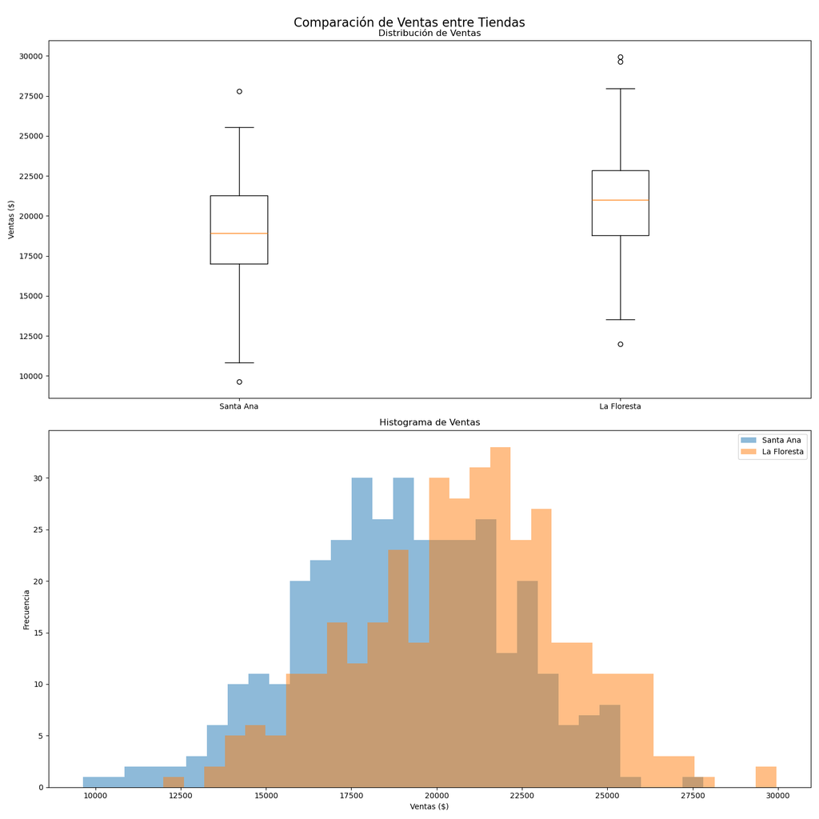

### Las hipótesis planteadas.

- Hipótesis nula (H0): \

No hay diferencia significativa en las ventas de ambas tiendas. => La media de las ventas diarias de ambas tiendas no es significativamente diferente.

- Hipótesis alternativa (H1): \

En 'La Floresta' se vende menos que en'Santa Ana' => La media de las ventas diarias de 'La Floresta' es menor que la media de las ventas diarias de 'Santa Ana'.

## Análisis y conclusiones:

### c) Comparación entre tiendas:

**Para significancia del 95%:** NO hay evidencia suficiente para concluir que la tienda 'La Floresta' vende menos que la tienda 'Santa Ana'.

**Para significancia del 99%:** NO hay evidencia suficiente para concluir que la tienda 'La Floresta' vende menos que la tienda 'Santa Ana'.

### Recomendaciones para Don Francisco:

- Mes recomendado para vacaciones:

**Enero** *(basado en el mes con menores ventas en ambas tiendas)*